Author: Bibobra Alabrah title: United States of America Birth Records Analysis Dataset: US Present Birth Records Date: 6/7/2018 —

Import dependencies(libraries)

```r
library(dplyr)
```

```r
library(ggplot2)
library(statsr)
```

Load the dataset:

```r
data(present)
```

View the number of records and features of the dataset:

```r
dim(present)
```

```
## [1] 74  3
```

Rename the dataset to birth_records:

```r
birth_records <- present
rm(present)
```

View the first 10 records of the dataset

```r
head(birth_records, 10)
```

```
## # A tibble: 10 x 3
##     year    boys   girls
##    <dbl>   <dbl>   <dbl>
##  1  1940 1211684 1148715
##  2  1941 1289734 1223693
##  3  1942 1444365 1364631
##  4  1943 1508959 1427901
##  5  1944 1435301 1359499
##  6  1945 1404587 1330869
##  7  1946 1691220 1597452
##  8  1947 1899876 1800064
##  9  1948 1813852 1721216
## 10  1949 1826352 1733177
```

What years are included in this dataset?

```r
range(birth_records$year)
```

```
## [1] 1940 2013
```

We see that the birth records span from 1940 to 2013.

What is the total number of births for each year?

```r
birth_records <- birth_records %>%
  mutate(total = boys + girls)
head(birth_records)
```

```
## # A tibble: 6 x 4
##    year    boys   girls   total
##   <dbl>   <dbl>   <dbl>   <dbl>
## 1  1940 1211684 1148715 2360399
## 2  1941 1289734 1223693 2513427
## 3  1942 1444365 1364631 2808996
## 4  1943 1508959 1427901 2936860
## 5  1944 1435301 1359499 2794800
## 6  1945 1404587 1330869 2735456
```

What is the proportion of boys born each year?

```r
birth_records <- birth_records %>%
  mutate(prop_boys = boys/total)
head(birth_records$prop_boys)
```

```
## [1] 0.5133386 0.5131376 0.5141926 0.5138001 0.5135613 0.5134745
```

What about the proportion of girls?

```r
birth_records <- birth_records %>%
  mutate(prop_girls = girls/total)
head(birth_records$prop_girls)
```

```
## [1] 0.4866614 0.4868624 0.4858074 0.4861999 0.4864387 0.4865255
```

We can see that generally more boys were born during this time. Let us visualize this information.

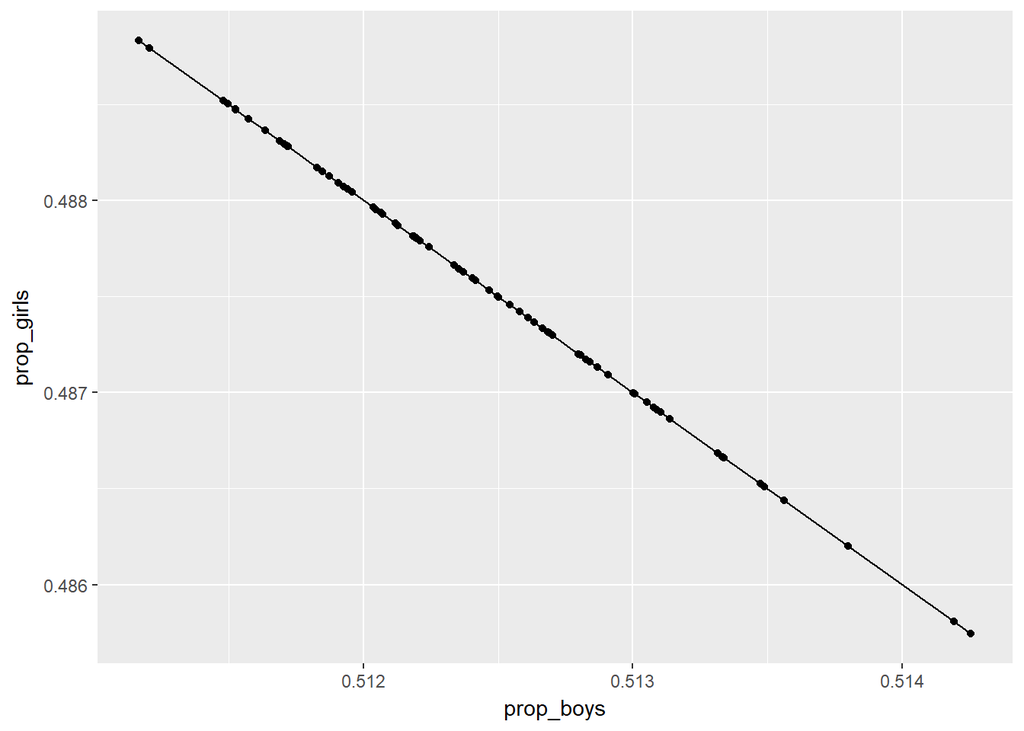

```r
ggplot(birth_records, aes(x = prop_boys, y = prop_girls)) +
  geom_point()+
  geom_line()
```

Let us Plot these values over time and based on the plot determine if the following statement is true or false: The proportion of boys born in the US has decreased over time.

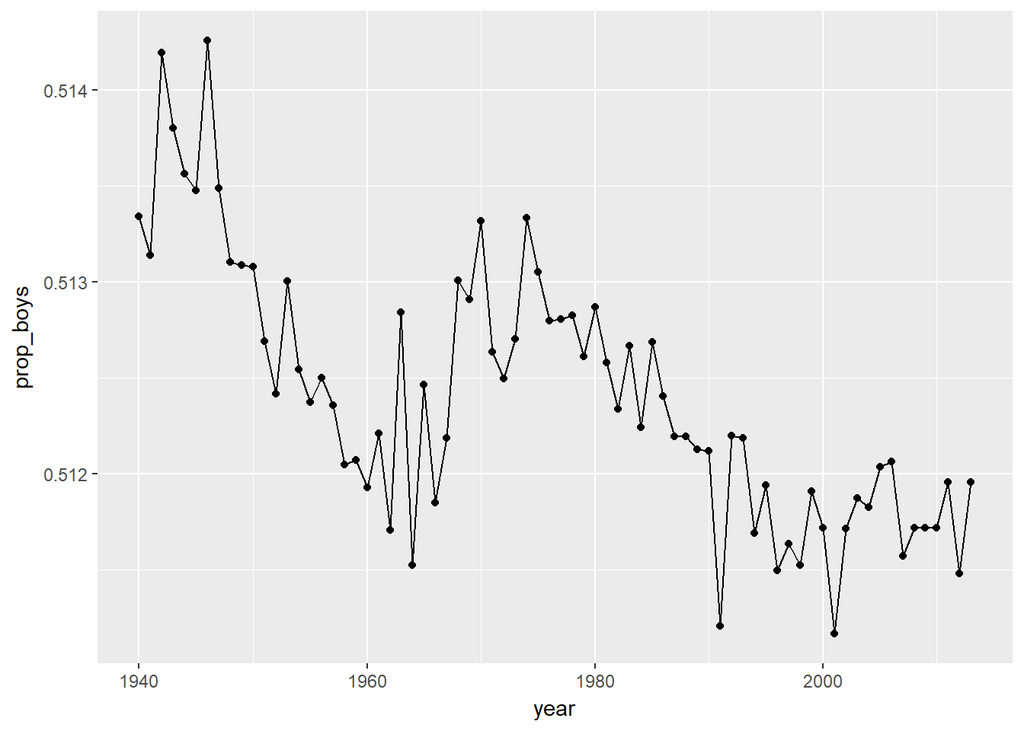

```r
ggplot(birth_records, aes(x = year, y = prop_boys)) +
  geom_point()+
  geom_line()
```

Based on the plot we can see that the proportion of boys born in the US has decreased over time.

Has the number of girls increased over time?

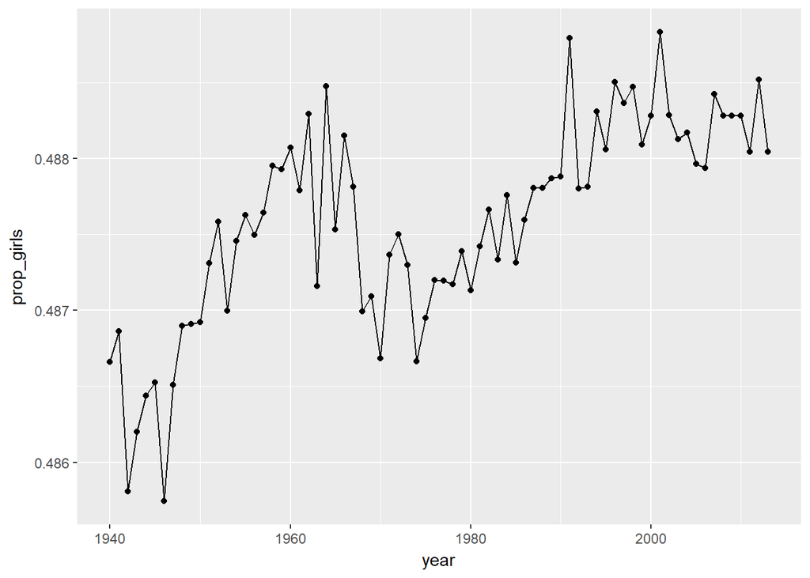

```r
ggplot(birth_records, aes(x = year, y = prop_girls)) +
  geom_point()+
  geom_line()
```

Based on the information, the number of girls has increased over time.

What is the boy to girl ratio for each?

```r
birth_records <- birth_records %>%
  mutate(prop_boy_girl = boys/girls)
```

Plot these values over time. Describe the observed trend?

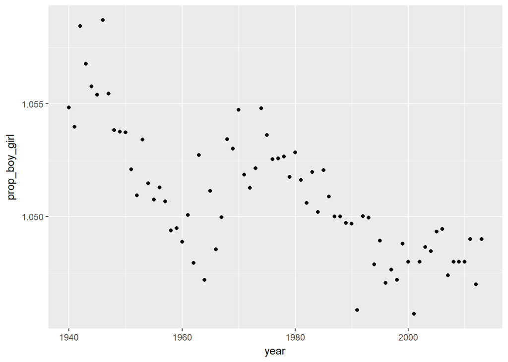

```r
ggplot(birth_records, aes(x = year, y = prop_boy_girl)) +
  geom_point()
```

There is initially a decrease in the boy-to-girl ratio, and then an increase between 1960 and 1970, followed by a decrease.

8. In what year did we see the most total number of births in the U.S.?

```r
birth_records %>%
 mutate(total = total) %>%
arrange(desc(total))
```

```
## # A tibble: 74 x 7
##     year    boys   girls   total prop_boys prop_girls prop_boy_girl
##    <dbl>   <dbl>   <dbl>   <dbl>     <dbl>      <dbl>         <dbl>
##  1  2007 2208071 2108162 4316233     0.512      0.488          1.05
##  2  1961 2186274 2082052 4268326     0.512      0.488          1.05
##  3  2006 2184237 2081318 4265555     0.512      0.488          1.05
##  4  1960 2179708 2078142 4257850     0.512      0.488          1.05
##  5  1957 2179960 2074824 4254784     0.512      0.488          1.05
##  6  2008 2173625 2074069 4247694     0.512      0.488          1.05
##  7  1959 2173638 2071158 4244796     0.512      0.488          1.05
##  8  1958 2152546 2051266 4203812     0.512      0.488          1.05
##  9  1962 2132466 2034896 4167362     0.512      0.488          1.05
## 10  1956 2133588 2029502 4163090     0.513      0.487          1.05
## # ... with 64 more rows
```

We see that the US had the most total number of births in 2007.